# Exercises Laboratory Session 01

Nicola Zomer

31 March, 2022

```r
knitr::opts_chunk$set(dev = "ragg_png")
```

```r
# tidyverse
library(ggplot2)
library(readr)
library(tibble)
library(glue)

# others
library(latex2exp)
library(scales)
library(kableExtra)
```

# Exercise 1 - Vectors and data frames

```r
df_lakes <- read.csv("../../data/lochs_of_Scotland.csv", header=TRUE, sep=",")
df_lakes %>%
  kbl() %>%
  kable_styling()
```

| Loch | Volume.km.3. | Volume.mi.3. | Area.km.2. | Area.mi.2. | Length.km. | Length.mi. | Max..depth.m. | Max..depth.ft. | Mean.depth.m. | Mean.depth.ft. |
| --- | --- | --- | --- | --- | --- | --- | --- | --- | --- | --- |
| Loch Ness | 7.45 | 1.790 | 56.0 | 22.0 | 36.2 | 22.5 | 227 | 745 | 132.0 | 433 |
| Loch Lomond | 2.60 | 0.620 | 71.0 | 27.0 | 36.0 | 22.0 | 190 | 620 | 37.0 | 121 |
| Loch Morar | 2.30 | 0.550 | 26.7 | 10.3 | 18.8 | 11.7 | 310 | 1020 | 87.0 | 285 |
| Loch Tay | 1.60 | 0.380 | 26.4 | 10.2 | 23.0 | 14.0 | 150 | 490 | 60.6 | 199 |
| Loch Awe | 1.20 | 0.290 | 39.0 | 15.0 | 41.0 | 25.0 | 94 | 308 | 32.0 | 105 |
| Loch Maree | 1.09 | 0.260 | 28.6 | 11.0 | 20.0 | 12.0 | 114 | 374 | 38.0 | 125 |
| Loch Ericht | 1.08 | 0.260 | 18.6 | 7.2 | 23.0 | 14.0 | 156 | 512 | 57.6 | 189 |
| Loch Lochy | 1.07 | 0.260 | 16.0 | 6.2 | 16.0 | 9.9 | 162 | 531 | 70.0 | 230 |
| Loch Rannoch | 0.97 | 0.230 | 19.0 | 7.3 | 15.7 | 9.8 | 134 | 440 | 51.0 | 167 |
| Loch Shiel | 0.79 | 0.190 | 19.5 | 7.5 | 28.0 | 17.0 | 128 | 420 | 40.0 | 130 |
| Loch Katrine | 0.77 | 0.180 | 12.4 | 4.8 | 12.9 | 8.0 | 151 | 495 | 43.4 | 142 |
| Loch Arkaig | 0.75 | 0.180 | 16.0 | 6.2 | 19.3 | 12.0 | 109 | 358 | 46.5 | 153 |
| Loch Shin | 0.35 | 0.084 | 22.5 | 8.7 | 27.8 | 17.3 | 49 | 161 | 15.5 | 51 |

```r
# Remove columns not containing volume or area and in [mi]
df_lakes <- df_lakes[, c(1, 2, 4)]

# Rename the columns
colnames(df_lakes) <- c('Loch', 'Volume', 'Area')
df_lakes %>%
  kbl() %>%
  kable_styling()
```

| Loch | Volume | Area |
| --- | --- | --- |
| Loch Ness | 7.45 | 56.0 |
| Loch Lomond | 2.60 | 71.0 |
| Loch Morar | 2.30 | 26.7 |
| Loch Tay | 1.60 | 26.4 |
| Loch Awe | 1.20 | 39.0 |
| Loch Maree | 1.09 | 28.6 |
| Loch Ericht | 1.08 | 18.6 |
| Loch Lochy | 1.07 | 16.0 |
| Loch Rannoch | 0.97 | 19.0 |
| Loch Shiel | 0.79 | 19.5 |
| Loch Katrine | 0.77 | 12.4 |
| Loch Arkaig | 0.75 | 16.0 |
| Loch Shin | 0.35 | 22.5 |

## 1. Evaluate the highest and lowest volume and area lake

```r
# indices
idx_max_vol <- which.max(df_lakes$Volume)
idx_min_vol <- which.min(df_lakes$Volume)
idx_max_area <- which.max(df_lakes$Area)
idx_min_area <- which.min(df_lakes$Area)

# results

cat(
  'Highest volume lake:', df_lakes$Loch[idx_max_vol], ', with volume ', df_lakes$Volume[idx_max_vol], 'km^3\n',
  'Lowest volume lake:', df_lakes$Loch[idx_min_vol], ', with volume ', df_lakes$Volume[idx_min_vol], 'km^3\n',
  'Highest area lake:', df_lakes$Loch[idx_max_area], ', with area ', df_lakes$Area[idx_max_area], 'km^2\n',
  'Lowest area lake:', df_lakes$Loch[idx_min_area], ', with area ', df_lakes$Area[idx_min_area], 'km^2'

  )
```

```
## Highest volume lake: Loch Ness , with volume  7.45 km^3
##  Lowest volume lake: Loch Shin , with volume  0.35 km^3
##  Highest area lake: Loch Lomond , with area  71 km^2
##  Lowest area lake: Loch Katrine , with area  12.4 km^2
```

## 2. Order the frame with respect to the area and determine the two largest area lakes

Ordered dataframe:

```r
lakes_byarea <- df_lakes[order(df_lakes$Area, decreasing=TRUE), ]
lakes_byarea %>%
  kbl() %>%
  kable_styling()
```

|  | Loch | Volume | Area |
| --- | --- | --- | --- |
| 2 | Loch Lomond | 2.60 | 71.0 |
| 1 | Loch Ness | 7.45 | 56.0 |
| 5 | Loch Awe | 1.20 | 39.0 |
| 6 | Loch Maree | 1.09 | 28.6 |
| 3 | Loch Morar | 2.30 | 26.7 |
| 4 | Loch Tay | 1.60 | 26.4 |
| 13 | Loch Shin | 0.35 | 22.5 |
| 10 | Loch Shiel | 0.79 | 19.5 |
| 9 | Loch Rannoch | 0.97 | 19.0 |
| 7 | Loch Ericht | 1.08 | 18.6 |
| 8 | Loch Lochy | 1.07 | 16.0 |
| 12 | Loch Arkaig | 0.75 | 16.0 |
| 11 | Loch Katrine | 0.77 | 12.4 |

```r
largest_area_2 = lakes_byarea$Loch[1:2]

glue('2 largest area lakes: {largest_area_2[1]} and {largest_area_2[2]}')
```

```
## 2 largest area lakes: Loch Lomond and Loch Ness
```

## 3. By summing up the areas occupied by the lakes, determine the area of Scotland covered by water

```r
area_water <- sum(df_lakes$Area)
glue('Area of Scotland covered by water: {area_water} km^2')
```

```
## Area of Scotland covered by water: 371.7 km^2
```

Reference and data: https://en.wikipedia.org/wiki/List_of_lochs_of_Scotland

# Exercise 2 - Crude Oil Production

## 1. Write R code that is able to read the file and import it in a data frame structure

The last column of the data frame contains data on crude oil prices from 1861 to 2020, measured in US dollars per barrel.

```r
df_oilprices <- read.csv("../../data/crude-oil-prices.csv", header=TRUE, sep=",")
colnames(df_oilprices) <- c(names(df_oilprices[1:3]), 'Price')

str(df_oilprices)
```

```
## 'data.frame':    160 obs. of  4 variables:
##  $ Entity: chr  "World" "World" "World" "World" ...
##  $ Code  : chr  "OWID_WRL" "OWID_WRL" "OWID_WRL" "OWID_WRL" ...
##  $ Year  : int  1861 1862 1863 1864 1865 1866 1867 1868 1869 1870 ...
##  $ Price : num  0.49 1.05 3.15 8.06 6.59 3.74 2.41 3.63 3.64 3.86 ...
```

## 2. Produce a plot with the Oil price as a function of the year

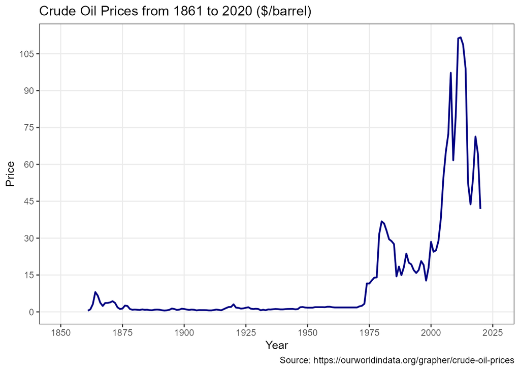

```r
gg <- ggplot(df_oilprices, aes(x=Year, y=Price))+
  geom_line(col='navyblue', size=0.8) +
  labs(title="Crude Oil Prices from 1861 to 2020 ($/barrel)",
       y="Price",
       x='Year',
       caption = "Source: https://ourworldindata.org/grapher/crude-oil-prices") +
  scale_y_continuous(
    breaks = seq(0, 120, 15),
    minor_breaks = NULL
  ) +
  scale_x_continuous(
    breaks = seq(1850, 2050, 25),
    minor_breaks = NULL,
    limits=c(1850, 2025)
  )+
  theme_bw()

plot(gg)
```

## 3. Which is the highest price in history ? When did it occur ?

```r
highest_price <- max(df_oilprices$Price)
highest_price_year <- df_oilprices$Year[which.max(df_oilprices$Price)]

glue('Highest price in hystory: {format(highest_price, digits=5)} $/barrel.\n
  It occured in {highest_price_year}.')
```

```
## Highest price in hystory: 111.67 $/barrel.
##
## It occured in 2012.
```

## 4. Plot the derivative of the curve, simply evaluated with the finite difference formula

$$\frac{\partial price}{\partial year} = price_{j+1}-price{j}$$

```r
prices <- df_oilprices$Price
years <- df_oilprices$Year
derivatives <- prices[2:length(prices)]-prices[1:length(prices)-1]

df_derivatives <- data.frame(years[1:length(years)-1], derivatives)
colnames(df_derivatives) <- c('Year', 'Derivative')

str(df_derivatives)
```

```
## 'data.frame':    159 obs. of  2 variables:
##  $ Year      : int  1861 1862 1863 1864 1865 1866 1867 1868 1869 1870 ...
##  $ Derivative: num  0.56 2.1 4.91 -1.47 -2.85 ...
```

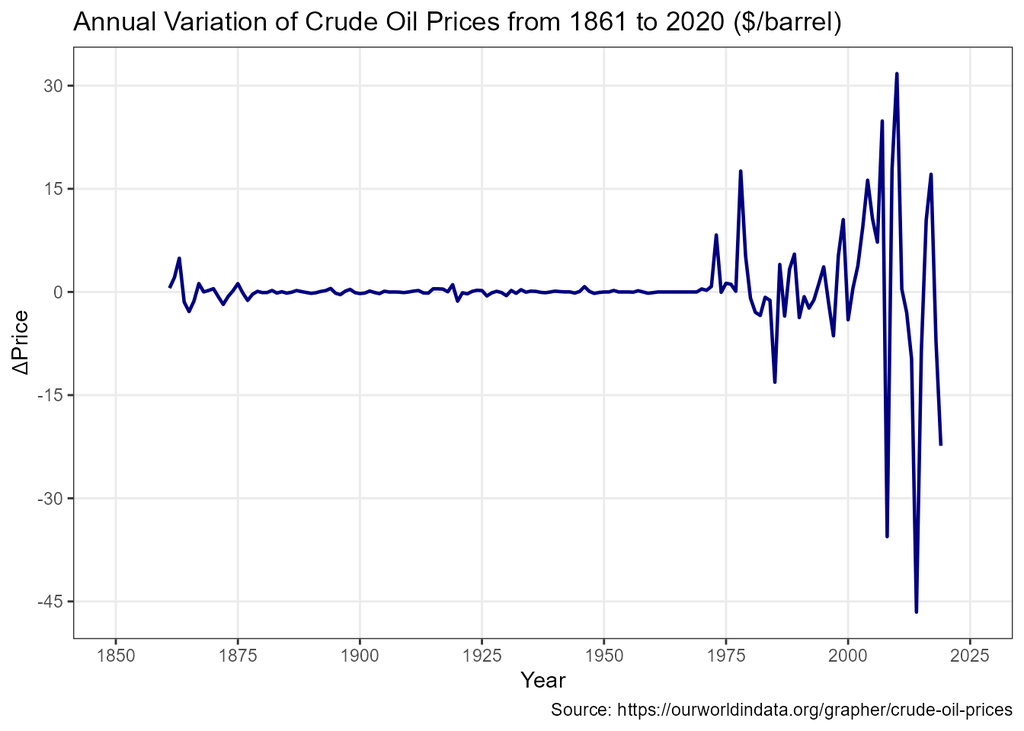

```r
gg <- ggplot(df_derivatives, aes(x=Year, y=Derivative))+
  geom_line(col='navyblue', size=0.8) +
  labs(title="Annual Variation of Crude Oil Prices from 1861 to 2020 ($/barrel)",
       y=TeX("$\\Delta$Price"),
       x='Year',
       caption = "Source: https://ourworldindata.org/grapher/crude-oil-prices") +
  scale_x_continuous(
    breaks = seq(1850, 2050, 25),
    minor_breaks = NULL,
    limits=c(1850, 2025)
  ) +
  scale_y_continuous(
    breaks = seq(-45, 45, 15),
    minor_breaks = NULL,
  )+
  theme_bw()

plot(gg)
```

Reference and data: https://ourworldindata.org/grapher/crude-oil-prices

# Exercise 3 - World Coal Production

## 1. Write R code that is able to read the file and import it in a tibble structure

```r
coal_prod <- read_csv("../../data/coal-production-by-country.csv", col_names=TRUE)
colnames(coal_prod) <- c(names(coal_prod[1:3]), 'Production')

kable(head(coal_prod)) %>%
  kable_styling()
```

| Entity | Code | Year | Production |
| --- | --- | --- | --- |
| Afghanistan | AFG | 1900 | 0 |
| Afghanistan | AFG | 1901 | 0 |
| Afghanistan | AFG | 1902 | 0 |
| Afghanistan | AFG | 1903 | 0 |
| Afghanistan | AFG | 1904 | 0 |
| Afghanistan | AFG | 1905 | 0 |

```r
is_tibble(coal_prod)
```

```
## [1] TRUE
```

## 2. Count the number of countries available in the file and produce a barplot with the number of entries for each country

```r
countries <- unique(coal_prod$Entity)
cat('Number of countries:', length(countries))
```

```
## Number of countries: 200
```

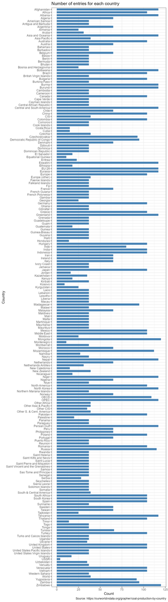

```r
gg <- ggplot(data=coal_prod, aes(x=Entity)) +
  geom_bar(stat = "count", width=0.7, fill="steelblue") +
  coord_flip() +
  scale_x_discrete(limits=rev) +
  labs(title="Number of entries for each country",
       x="Country",
       y="Count",
       caption = "Source: https://ourworldindata.org/grapher/coal-production-by-country") +
  theme_bw()

gg
```

For the following items select only the years
$$\geq$$
1970.

## 3. Selecting only the year after 1970, determine the total integrated production for each country and print the top 5 countries with highest coal productions

```r
# select only the years after 1970
coal_prod_1970 <- coal_prod[coal_prod['Year']>1970, ]

# total integrated production for each country
int_prod_1970 <- aggregate(coal_prod_1970$Production, by=list(coal_prod_1970$Entity), FUN=sum)
colnames(int_prod_1970) <- c('Country', 'IntProd')

# top 5 countries
int_prod_1970[order(int_prod_1970$IntProd, decreasing = TRUE)[1:5], ] %>%
  kbl() %>%
  kable_styling()
```

|  | Country | IntProd |
| --- | --- | --- |
| 176 | World | 1260113.2 |
| 9 | Asia Pacific | 690240.5 |
| 8 | Asia and Oceania | 682343.9 |
| 32 | China | 459564.6 |
| 120 | OECD | 428754.2 |

As some elements are not countries, I want to remove these rows, and repeat the process until I get 5 countries.

```r
removed_elements = c('World', 'Asia Pacific', 'Asia and Oceania', 'OECD',
                     'North America', 'Eurasia', 'Europe', 'EU-28', 'CIS', 'Africa',
                     'South Africa'
                     ) # not all non-countries entries

int_prod_1970 <- int_prod_1970[!int_prod_1970$Country %in% removed_elements, ]

# top 5 countries
int_prod_1970[order(int_prod_1970$IntProd, decreasing = TRUE)[1:5], ] %>%
  kbl() %>%
  kable_styling()
```

|  | Country | IntProd |
| --- | --- | --- |
| 32 | China | 459564.65 |
| 166 | United States | 226068.84 |
| 135 | Russia | 98251.65 |
| 10 | Australia | 83077.07 |
| 77 | India | 77043.45 |

```r
top5_countries <- int_prod_1970$Country[order(int_prod_1970$IntProd, decreasing = TRUE)[1:5]]
```

## 4. For the 5 top Countries, create a plot of production as a function of time

```r
# create the reduced dataframe
df_top5 <- coal_prod_1970[coal_prod_1970$Entity %in% top5_countries, ]

# inspect the structure of the dataframe
str(df_top5)
```

```
## tibble [200 x 4] (S3: tbl_df/tbl/data.frame)
##  $ Entity    : chr [1:200] "Australia" "Australia" "Australia" "Australia" ...
##  $ Code      : chr [1:200] "AUS" "AUS" "AUS" "AUS" ...
##  $ Year      : num [1:200] 1981 1982 1983 1984 1985 ...
##  $ Production: num [1:200] 789 805 839 881 1074 ...
```

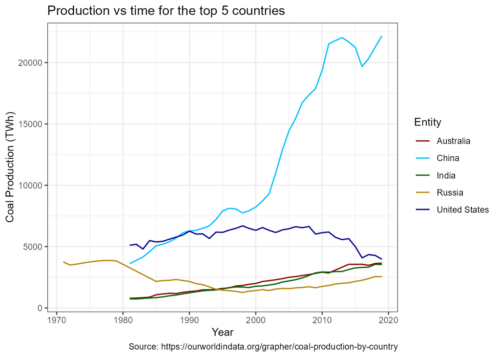

```r
colors <- c('darkred', 'deepskyblue', 'darkgreen', 'darkgoldenrod', 'darkblue')

ggplot(df_top5, aes(x = Year, y = Production)) +
  geom_line(aes(color = Entity), size=0.6) +
  scale_color_manual(values = colors)+
  labs(title="Production vs time for the top 5 countries",
       y="Coal Production (TWh)",
       caption = "Source: https://ourworldindata.org/grapher/coal-production-by-country") +
  theme_bw()
```

## 5. Generate a plot with the cumulative sum of the World’s coal production over the years

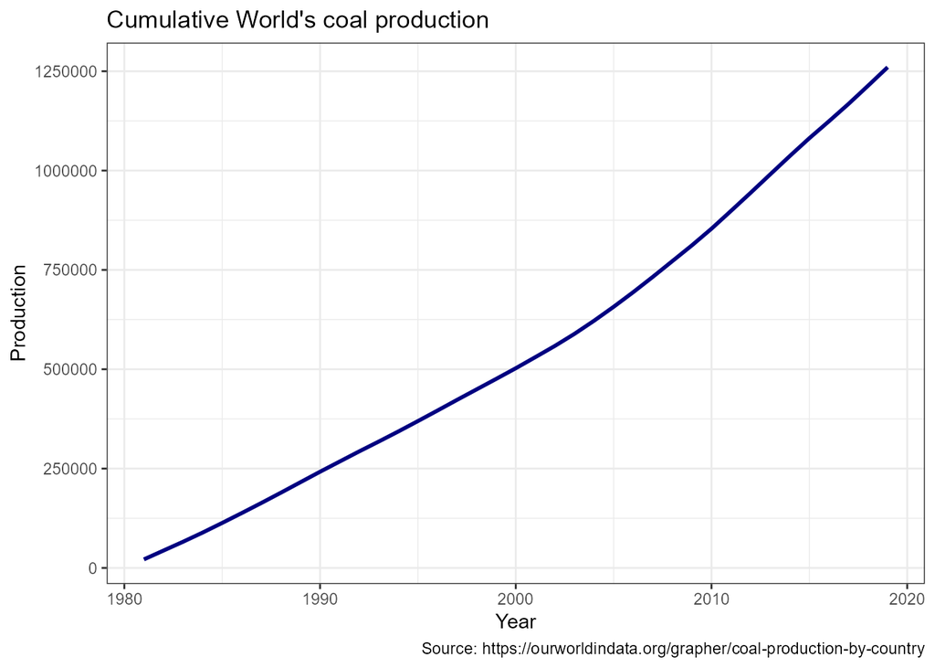

```r
world_cum <- cumsum(coal_prod_1970$Production[coal_prod_1970$Entity=='World'])
years <- coal_prod_1970$Year[coal_prod_1970$Entity=='World']

ggplot() +
  geom_line(aes(x=years, y=world_cum), col='navyblue', size=1) +
  labs(title="Cumulative World's coal production",
       x="Year",
       y="Production",
       caption = "Source: https://ourworldindata.org/grapher/coal-production-by-country") +
  theme_bw()
```

Reference and data: https://ourworldindata.org/grapher/coal-production-by-country

# Exercise 4 - Covid19 Vaccine data

## File ‘vaccinations-by-manufacturer.csv’

### 1. Filter() the original tibble by selecting the following countries: Italy

```r
# load the data
urlfile = "https://raw.githubusercontent.com/owid/covid-19-data/master/public/data/vaccinations/vaccinations-by-manufacturer.csv"
vacc_bymanu <- read_csv(url(urlfile), col_names=TRUE)
glimpse(vacc_bymanu)
```

```
## Rows: 35,810
## Columns: 4
## $ location           <chr> "Argentina", "Argentina", "Argentina", "Argentina",~
## $ date               <date> 2020-12-29, 2020-12-29, 2020-12-29, 2020-12-29, 20~
## $ vaccine            <chr> "Moderna", "Oxford/AstraZeneca", "Sinopharm/Beijing~
## $ total_vaccinations <dbl> 2, 4, 1, 20481, 2, 4, 1, 40583, 2, 4, 1, 43388, 2, ~
```

```r
# select only data related to Italy
vacc_Italy <- vacc_bymanu[vacc_bymanu$location=='Italy',]
head(vacc_Italy) %>%
  kbl() %>%
  kable_styling()
```

| location | date | vaccine | total_vaccinations |
| --- | --- | --- | --- |
| Italy | 2020-12-27 | Moderna | 2 |
| Italy | 2020-12-27 | Pfizer/BioNTech | 7347 |
| Italy | 2020-12-28 | Moderna | 6 |
| Italy | 2020-12-28 | Pfizer/BioNTech | 8848 |
| Italy | 2020-12-29 | Moderna | 11 |
| Italy | 2020-12-29 | Pfizer/BioNTech | 9942 |

### 2. Plot the number of vaccines given as a function of time for the different vaccine manufacturer

```r
# inspect the manufacturers
unique(vacc_Italy$vaccine)
```

```
## [1] "Moderna"            "Pfizer/BioNTech"    "Johnson&Johnson"
## [4] "Oxford/AstraZeneca" "Novavax"
```

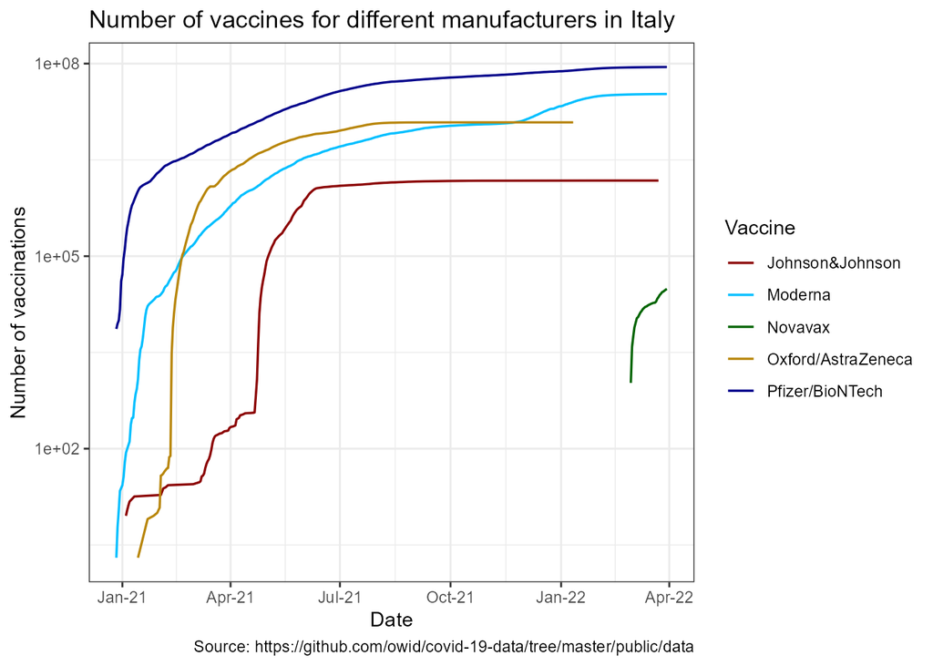

```r
colors <- c('darkred', 'deepskyblue', 'darkgreen', 'darkgoldenrod', 'darkblue')

gg <- ggplot(vacc_Italy, aes(x = date, y = total_vaccinations)) +
  geom_line(aes(color = vaccine), size=0.6) +
  scale_color_manual(values = colors)+
  labs(title="Number of vaccines for different manufacturers in Italy",
       x='Date',
       y='Number of vaccinations',
       color='Vaccine',
       caption = "Source: https://github.com/owid/covid-19-data/tree/master/public/data") +
  scale_y_continuous(trans='log10') +
  scale_x_date(
    breaks = seq(as.Date("2021-01-01"), as.Date("2022-04-01"), by = "quarter"),
    date_labels="%b-%y")+
  theme_bw()

plot(gg)
```

### 3. From the same tibble plot the total number of vaccines shot per day in Italy

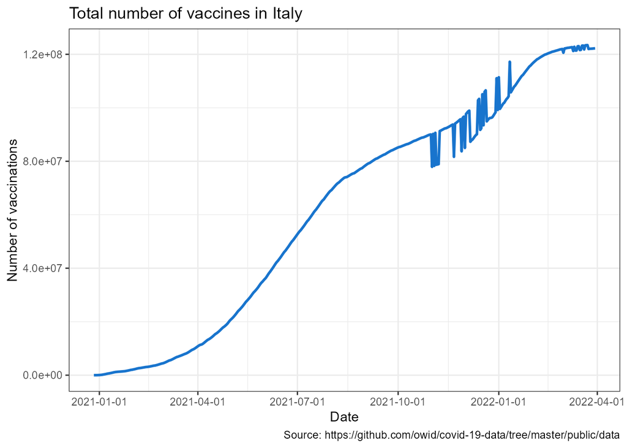

```r
tot_vacc_Italy <- aggregate(vacc_Italy$total_vaccinations, by=list(vacc_Italy$date), FUN=sum)
colnames(tot_vacc_Italy) <- c('date', 'tot_vaccinations')


gg <- ggplot(tot_vacc_Italy, aes(x = date, y = tot_vaccinations)) +
  geom_line(col='dodgerblue3', size=1) +
  labs(title="Total number of vaccines in Italy",
       x='Date',
       y='Number of vaccinations',
       caption = "Source: https://github.com/owid/covid-19-data/tree/master/public/data") +
  scale_x_continuous(
    breaks = seq(as.Date("2021-01-01"), as.Date("2022-04-01"), by = "quarter"),
  ) +
  theme_bw()

plot(gg)
```

Probably due to the the missing information about Orford/AstraZeneca, after a certain date, the cumulative number of vaccines decreases at a certain point and does strange oscillations. This is absurd and cannot be justified.

This implies that if we try to get the number of vaccines per day by taking the difference between consecutive days, we get negative results, that is also absurd. Let’s fix this.

First of all, I want to find the exact dates on which the number of total vaccinations decreases.

```r
# tail(vacc_Italy$date[vacc_Italy$vaccine=='Oxford/AstraZeneca'], 1)

j=0
problematic_dates = c()
for (i in seq_along(tot_vacc_Italy$tot_vaccinations)){
  if (tot_vacc_Italy$tot_vaccinations[i]<j){
    problematic_dates <- append(problematic_dates, tot_vacc_Italy$date[i])
  }
  j=tot_vacc_Italy$tot_vaccinations[i]
}
kable(problematic_dates, col.names="Problematic Dates") %>%
  kable_styling()
```

| Problematic Dates |
| --- |
| 2021-11-01 |
| 2021-11-03 |
| 2021-11-05 |
| 2021-11-21 |
| 2021-11-28 |
| 2021-12-01 |
| 2021-12-06 |
| 2021-12-15 |
| 2021-12-18 |
| 2021-12-21 |
| 2021-12-31 |
| 2022-01-02 |
| 2022-01-12 |
| 2022-03-01 |
| 2022-03-10 |
| 2022-03-12 |
| 2022-03-16 |
| 2022-03-20 |
| 2022-03-24 |

Let’s see if we know the total Oxford/Astrazeneca vaccinations on these days.

```r
for (i in seq_along(problematic_dates)){
  tmp <- vacc_Italy[
    (vacc_Italy$date==problematic_dates[i]) &
      (vacc_Italy$vaccine=='Oxford/AstraZeneca'), ]
  is_not_empty <- as.logical(nrow(tmp))
  print(paste(problematic_dates[i], ': is it NOT empty?', is_not_empty))
}
```

```
## [1] "2021-11-01 : is it NOT empty? FALSE"
## [1] "2021-11-03 : is it NOT empty? FALSE"
## [1] "2021-11-05 : is it NOT empty? FALSE"
## [1] "2021-11-21 : is it NOT empty? FALSE"
## [1] "2021-11-28 : is it NOT empty? FALSE"
## [1] "2021-12-01 : is it NOT empty? FALSE"
## [1] "2021-12-06 : is it NOT empty? FALSE"
## [1] "2021-12-15 : is it NOT empty? FALSE"
## [1] "2021-12-18 : is it NOT empty? FALSE"
## [1] "2021-12-21 : is it NOT empty? FALSE"
## [1] "2021-12-31 : is it NOT empty? FALSE"
## [1] "2022-01-02 : is it NOT empty? FALSE"
## [1] "2022-01-12 : is it NOT empty? FALSE"
## [1] "2022-03-01 : is it NOT empty? FALSE"
## [1] "2022-03-10 : is it NOT empty? FALSE"
## [1] "2022-03-12 : is it NOT empty? FALSE"
## [1] "2022-03-16 : is it NOT empty? FALSE"
## [1] "2022-03-20 : is it NOT empty? FALSE"
## [1] "2022-03-24 : is it NOT empty? FALSE"
```

```r
print(paste('Last information about Oxford/AstraZeneca vaccine in ',
            tail(vacc_Italy$date[vacc_Italy$vaccine=='Oxford/AstraZeneca'], 1)))
```

```
## [1] "Last information about Oxford/AstraZeneca vaccine in  2022-01-11"
```

As expected I have no information on Oxford/AstraZeneca vaccines on these dates and after Jan 22. This causes the graph of the total number of vaccinations to drop. Moreover, notice how the same problem arises even after this date, a sign that some data relating to other pharmaceutical companies is also missing.

**This is what I will try to fix the problem:**

1. **Break the plot in January 2022.** After this date in my opinion it has no meaning to show the total number of vaccinations. One possibility would be to extend the AstraZeneca plot, but this would mean assuming zero vaccinations of that type after January 2022. Since this is a strong assumption, I prefer to stop the study first, using only data that I believe to be reliable.
2. **Add the total number of vaccinations in the dates before January 2022 in which I have no information**. I set them to be equal to the value on the day before. Hopefully being single days this does not alter the results too much.

```r
# cut the dataframe
vacc_IT_fixed = vacc_Italy[vacc_Italy$date < '2022-01-01', ]

# add missing data
for (date in seq(as.Date("2021-01-14"), as.Date("2021-12-31"), by='day')){
  if (nrow(vacc_IT_fixed[
    (vacc_IT_fixed$date==date) & (vacc_IT_fixed$vaccine=='Oxford/AstraZeneca'),]
    )==0){

    tmp <- vacc_IT_fixed[(vacc_IT_fixed$date==date-1) &
                           (vacc_IT_fixed$vaccine=='Oxford/AstraZeneca'),]
    tmp$date = tmp$date+1
    vacc_IT_fixed[nrow(vacc_IT_fixed)+1, ] <- tmp

  }
}

# check
for (i in seq_along(problematic_dates)[1:11]){
 tmp <- vacc_IT_fixed[
   (vacc_IT_fixed$date==problematic_dates[i]) &
     (vacc_IT_fixed$vaccine=='Oxford/AstraZeneca'), ]
 is_not_empty <- as.logical(nrow(tmp))
 print(paste(problematic_dates[i], ': is it NOT empty?', is_not_empty))
}
```

```
## [1] "2021-11-01 : is it NOT empty? TRUE"
## [1] "2021-11-03 : is it NOT empty? TRUE"
## [1] "2021-11-05 : is it NOT empty? TRUE"
## [1] "2021-11-21 : is it NOT empty? TRUE"
## [1] "2021-11-28 : is it NOT empty? TRUE"
## [1] "2021-12-01 : is it NOT empty? TRUE"
## [1] "2021-12-06 : is it NOT empty? TRUE"
## [1] "2021-12-15 : is it NOT empty? TRUE"
## [1] "2021-12-18 : is it NOT empty? TRUE"
## [1] "2021-12-21 : is it NOT empty? TRUE"
## [1] "2021-12-31 : is it NOT empty? TRUE"
```

Let’s see how the cumulative distribution changed.

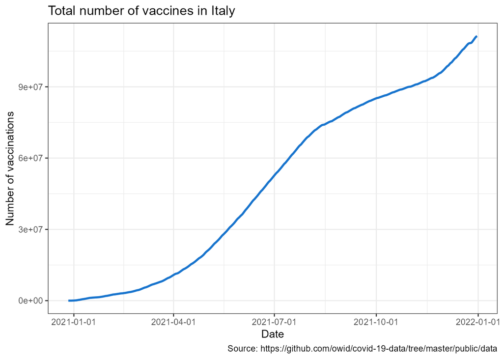

```r
tot_vacc_Italy <- aggregate(vacc_IT_fixed$total_vaccinations, by=list(vacc_IT_fixed$date), FUN=sum)
colnames(tot_vacc_Italy) <- c('date', 'tot_vaccinations')


gg <- ggplot(tot_vacc_Italy, aes(x = date, y = tot_vaccinations)) +
  geom_line(col='dodgerblue3', size=1) +
  labs(title="Total number of vaccines in Italy",
       x='Date',
       y='Number of vaccinations',
       caption = "Source: https://github.com/owid/covid-19-data/tree/master/public/data") +
  scale_x_continuous(
    breaks = seq(as.Date("2021-01-01"), as.Date("2022-01-01"), by = "quarter"),
  ) +
  theme_bw()

plot(gg)
```

It seems OK. Now I can evaluate the number of vaccinations per day.

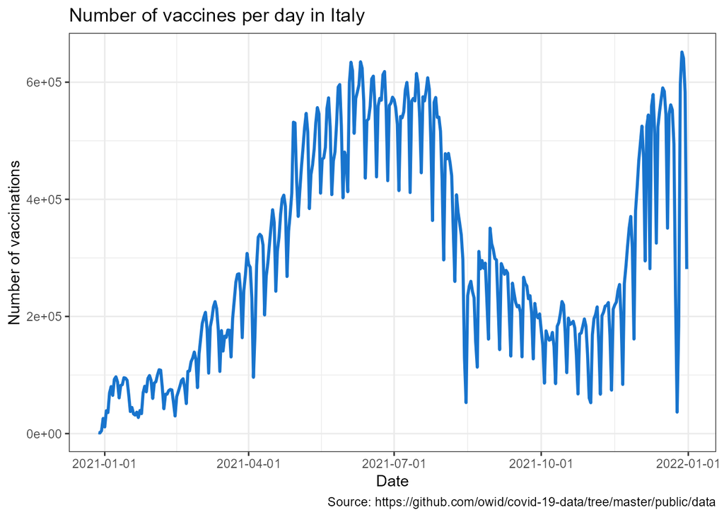

```r
tot_vacc_Italy_perday <- diff(tot_vacc_Italy$tot_vaccinations)
dates <- tot_vacc_Italy$date[2:length(tot_vacc_Italy$date)]

tot_vacc_Italy_perday <- data.frame(dates, tot_vacc_Italy_perday)
colnames(tot_vacc_Italy_perday) <- c('date', 'tot_vaccinations')

gg <- ggplot(tot_vacc_Italy_perday, aes(x = date, y = tot_vaccinations)) +
  geom_line(col='dodgerblue3', size=1) +
  labs(title="Number of vaccines per day in Italy",
       x='Date',
       y='Number of vaccinations',
       caption = "Source: https://github.com/owid/covid-19-data/tree/master/public/data") +
  scale_x_continuous(
    breaks = seq(as.Date("2021-01-01"), as.Date("2022-01-01"), by = "quarter"),
  ) +
  theme_bw()

plot(gg)
```

### 4. Do the same exercise for the following countries: Germany and United States of America

#### Germany

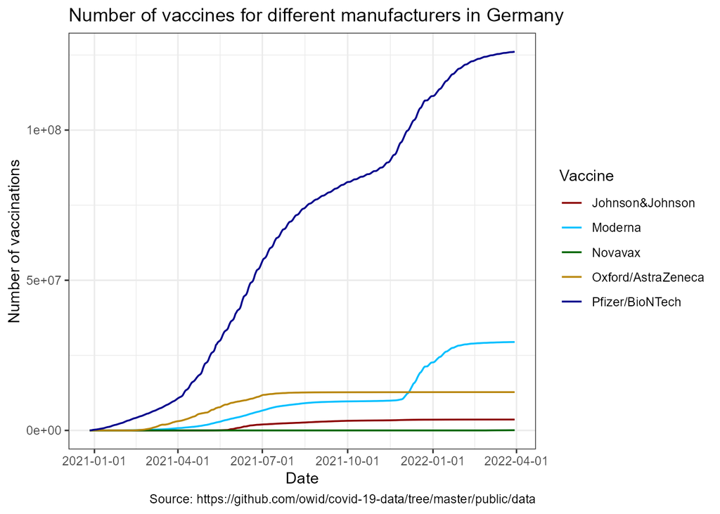

```r
# select only data related to Germany
vacc_Germany <- vacc_bymanu[vacc_bymanu$location=='Germany',]


# number of vaccines for the different manufacturers
colors <- c('darkred', 'deepskyblue', 'darkgreen', 'darkgoldenrod', 'darkblue')

G_num <- ggplot(vacc_Germany, aes(x = date, y = total_vaccinations)) +
  geom_line(aes(color = vaccine), size=0.6) +
  scale_color_manual(values = colors)+
  labs(title="Number of vaccines for different manufacturers in Germany",
       x='Date',
       y='Number of vaccinations',
       color='Vaccine',
       caption = "Source: https://github.com/owid/covid-19-data/tree/master/public/data") +
  scale_x_continuous(
    breaks = seq(as.Date("2021-01-01"), as.Date("2022-04-01"), by = "quarter"),
  ) +
  theme_bw()



# total number of vaccines per day in Germany
tot_vacc_Germany <- aggregate(vacc_Germany$total_vaccinations, by=list(vacc_Germany$date), FUN=sum)
colnames(tot_vacc_Germany) <- c('date', 'tot_vaccinations')

tot_vacc_Germany_perday <- diff(tot_vacc_Germany$tot_vaccinations)
dates <- tot_vacc_Germany$date[2:length(tot_vacc_Germany$date)]

tot_vacc_Germany_perday <- data.frame(dates, tot_vacc_Germany_perday)
colnames(tot_vacc_Germany_perday) <- c('date', 'tot_vaccinations')

G_perday <- ggplot(tot_vacc_Germany_perday, aes(x = date, y = tot_vaccinations)) +
  geom_line(col='dodgerblue3', size=1) +
  labs(title="Number of vaccines per day in Germany",
       x='Date',
       y='Number of vaccinations',
       caption = "Source: https://github.com/owid/covid-19-data/tree/master/public/data") +
  scale_x_continuous(
    breaks = seq(as.Date("2021-01-01"), as.Date("2022-04-01"), by = "quarter"),
  ) +
  theme_bw()



# plot the results
plot(G_num)
```

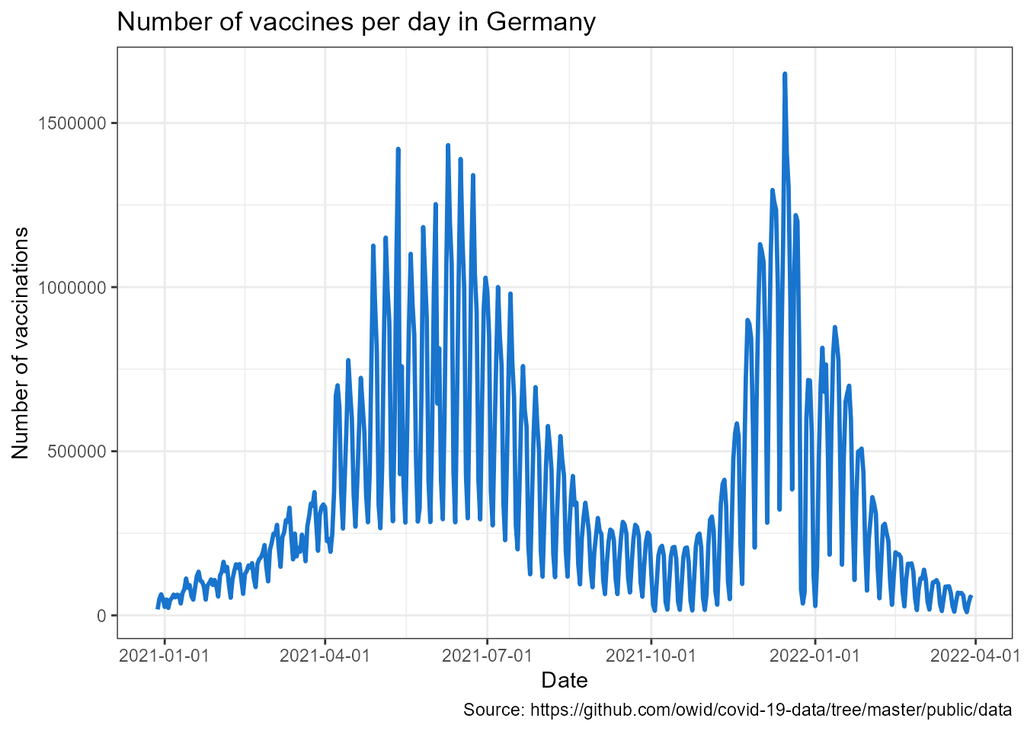

```r
plot(G_perday)
```

#### United States of America

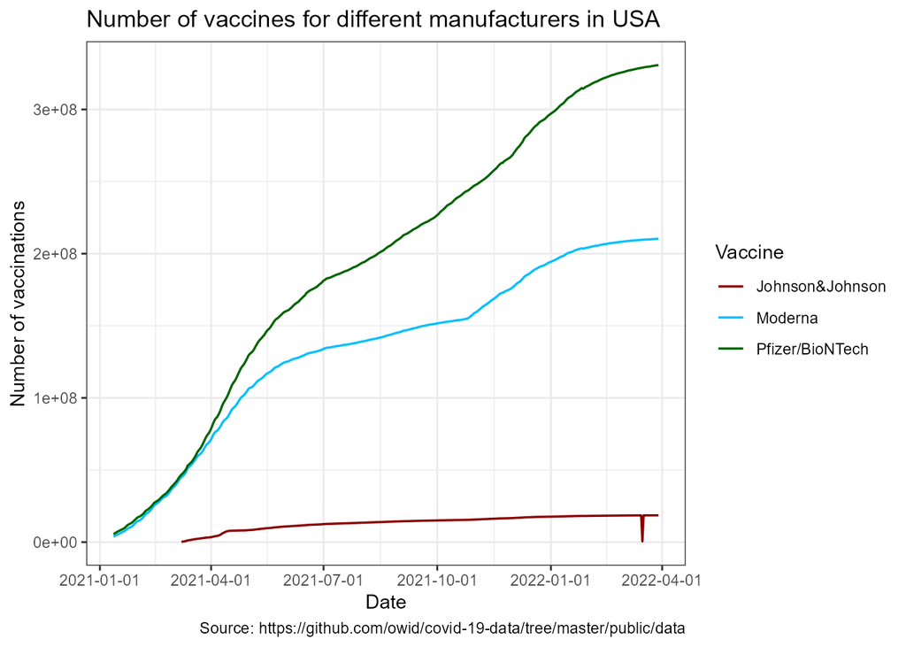

```r
# select only data related to Germany
vacc_USA <- vacc_bymanu[vacc_bymanu$location=='United States',]


# number of vaccines for the different manufacturers
colors <- c('darkred', 'deepskyblue', 'darkgreen', 'darkgoldenrod', 'darkblue')

USA_num <- ggplot(vacc_USA, aes(x = date, y = total_vaccinations)) +
  geom_line(aes(color = vaccine), size=0.6) +
  scale_color_manual(values = colors)+
  labs(title="Number of vaccines for different manufacturers in USA",
       x='Date',
       y='Number of vaccinations',
       color='Vaccine',
       caption = "Source: https://github.com/owid/covid-19-data/tree/master/public/data") +
  scale_x_continuous(
    breaks = seq(as.Date("2021-01-01"), as.Date("2022-04-01"), by = "quarter"),
  ) +
  theme_bw()



# total number of vaccines per day in USA
tot_vacc_USA <- aggregate(vacc_USA$total_vaccinations, by=list(vacc_USA$date), FUN=sum)
colnames(tot_vacc_USA) <- c('date', 'tot_vaccinations')

tot_vacc_USA_perday <- diff(tot_vacc_USA$tot_vaccinations)
dates <- tot_vacc_USA$date[2:length(tot_vacc_USA$date)]

tot_vacc_USA_perday <- data.frame(dates, tot_vacc_USA_perday)
colnames(tot_vacc_USA_perday) <- c('date', 'tot_vaccinations')

USA_perday <- ggplot(tot_vacc_USA_perday, aes(x = date, y = tot_vaccinations)) +
  geom_line(col='dodgerblue3', size=1) +
  labs(title="Number of vaccines per day in USA",
       x='Date',
       y='Number of vaccinations',
       caption = "Source: https://github.com/owid/covid-19-data/tree/master/public/data") +
  scale_x_continuous(
    breaks = seq(as.Date("2021-01-01"), as.Date("2022-04-01"), by = "quarter"),
  ) +
  theme_bw()



# plot the results
plot(USA_num)
```

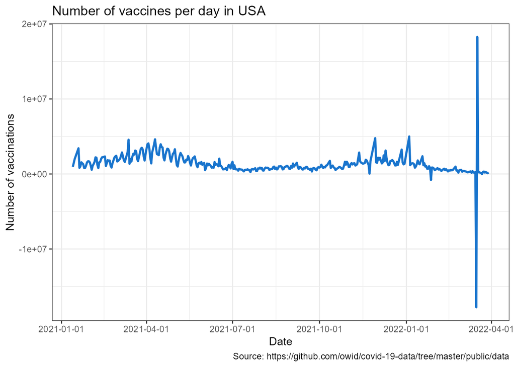

```r
plot(USA_perday)
```

Notice that around March 2022 there are some outliers for Johnson & Johnson. These cause an incorrect behavior in the vaccine per day curve, which shows negative values over that period, due to a negative difference in the total number of vaccine given. To solve this problem, I will consider the trend of the total number of Johnson & Johnson vaccines linear over that time interval.

```r
# find the initial and final wrong samples
df_JJ <- vacc_USA[vacc_USA$vaccine=='Johnson&Johnson', ]

date = as.Date('2022-03-01')
first_date = as.Date('2022-03-01')
last_date = as.Date('2022-03-01')

first_found = FALSE
last_found = FALSE

while (first_found == FALSE && last_found == FALSE && date<tail(df_JJ$date, 1)){
  if (df_JJ$total_vaccinations[df_JJ$date==date+1]<df_JJ$total_vaccinations[df_JJ$date==date]){
    if (first_found==FALSE){
      first_date = date
      vacc_broken = df_JJ$total_vaccinations[df_JJ$date==date]
      first_found=TRUE
    }
  }
  else if (first_found==TRUE){
    if (df_JJ$total_vaccinations[df_JJ$date==date+1] > vacc_broken){
      last_date = date+1
      print(last_date)
      last_found=TRUE
    }
  }
  date = date + 1
}

if (first_date == '2022-03-01') {
  print('Strange, there is no problem')
} else if (last_date == '2022-03-01') {
  corr_date = first_date+1
  print(paste('There is only one corrupted sample:', corr_date))
} else {
  print(paste('Problems begin after: ', first_date))
  print(paste('Problems end at: ', last_date))
}
```

```
## [1] "There is only one corrupted sample: 2022-03-16"
```

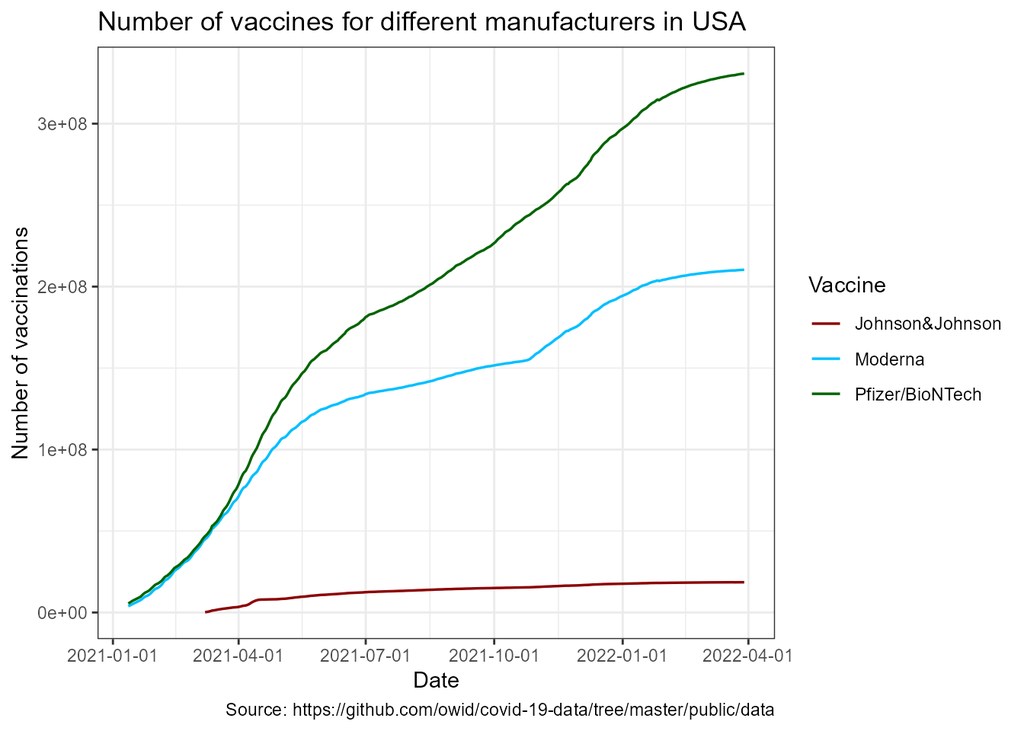

```r
# fix it
tmp <- vacc_USA[(vacc_USA$vaccine=='Johnson&Johnson') & (vacc_USA$date==corr_date), ]
tmp$total_vaccinations <-
  (vacc_USA$total_vaccinations[(vacc_USA$vaccine=='Johnson&Johnson') & (vacc_USA$date==corr_date-1)]+
  vacc_USA$total_vaccinations[(vacc_USA$vaccine=='Johnson&Johnson') & (vacc_USA$date==corr_date+1)])/2

vacc_USA[(vacc_USA$vaccine=='Johnson&Johnson') & (vacc_USA$date==corr_date), ] <- tmp

# PLOT THE CORRECTED DISTRIBUTIONS
# number of vaccines for the different manufacturers
USA_num <- ggplot(vacc_USA, aes(x = date, y = total_vaccinations)) +
  geom_line(aes(color = vaccine), size=0.6) +
  scale_color_manual(values = colors)+
  labs(title="Number of vaccines for different manufacturers in USA",
       x='Date',
       y='Number of vaccinations',
       color='Vaccine',
       caption = "Source: https://github.com/owid/covid-19-data/tree/master/public/data") +
  scale_x_continuous(
    breaks = seq(as.Date("2021-01-01"), as.Date("2022-04-01"), by = "quarter"),
  ) +
  theme_bw()

# total number of vaccines per day in USA
tot_vacc_USA <- aggregate(vacc_USA$total_vaccinations, by=list(vacc_USA$date), FUN=sum)
colnames(tot_vacc_USA) <- c('date', 'tot_vaccinations')

tot_vacc_USA_perday <- diff(tot_vacc_USA$tot_vaccinations)
dates <- tot_vacc_USA$date[2:length(tot_vacc_USA$date)]

tot_vacc_USA_perday <- data.frame(dates, tot_vacc_USA_perday)
colnames(tot_vacc_USA_perday) <- c('date', 'tot_vaccinations')

USA_perday <- ggplot(tot_vacc_USA_perday, aes(x = date, y = tot_vaccinations)) +
  geom_line(col='dodgerblue3', size=1) +
  labs(title="Number of vaccines per day in USA",
       x='Date',
       y='Number of vaccinations',
       caption = "Source: https://github.com/owid/covid-19-data/tree/master/public/data") +
  scale_x_continuous(
    breaks = seq(as.Date("2021-01-01"), as.Date("2022-04-01"), by = "quarter"),
  ) +
  theme_bw()


# plot the results
plot(USA_num)
```

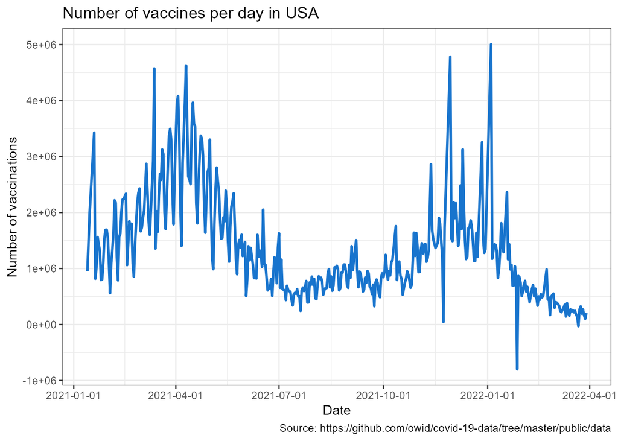

```r
plot(USA_perday)
```

Data: https://github.com/owid/covid-19-data/blob/master/public/data/vaccinations/vaccinations-by-manufacturer.csv

## File ‘vaccinations.csv’

### 1. Selecting all the European countries in the tibble, plot the number of daily vaccinations per million as a function of date

```r
# load the data
urlfile = "https://raw.githubusercontent.com/owid/covid-19-data/master/public/data/vaccinations/vaccinations.csv"
df_vacc <- read_csv(url(urlfile), col_names=TRUE)
glimpse(df_vacc)
```

```
## Rows: 92,207
## Columns: 16
## $ location                            <chr> "Afghanistan", "Afghanistan", "Afg~
## $ iso_code                            <chr> "AFG", "AFG", "AFG", "AFG", "AFG",~
## $ date                                <date> 2021-02-22, 2021-02-23, 2021-02-2~
## $ total_vaccinations                  <dbl> 0, NA, NA, NA, NA, NA, 8200, NA, N~
## $ people_vaccinated                   <dbl> 0, NA, NA, NA, NA, NA, 8200, NA, N~
## $ people_fully_vaccinated             <dbl> NA, NA, NA, NA, NA, NA, NA, NA, NA~
## $ total_boosters                      <dbl> NA, NA, NA, NA, NA, NA, NA, NA, NA~
## $ daily_vaccinations_raw              <dbl> NA, NA, NA, NA, NA, NA, NA, NA, NA~
## $ daily_vaccinations                  <dbl> NA, 1367, 1367, 1367, 1367, 1367, ~
## $ total_vaccinations_per_hundred      <dbl> 0.00, NA, NA, NA, NA, NA, 0.02, NA~
## $ people_vaccinated_per_hundred       <dbl> 0.00, NA, NA, NA, NA, NA, 0.02, NA~
## $ people_fully_vaccinated_per_hundred <dbl> NA, NA, NA, NA, NA, NA, NA, NA, NA~
## $ total_boosters_per_hundred          <dbl> NA, NA, NA, NA, NA, NA, NA, NA, NA~
## $ daily_vaccinations_per_million      <dbl> NA, 34, 34, 34, 34, 34, 34, 40, 45~
## $ daily_people_vaccinated             <dbl> NA, 1367, 1367, 1367, 1367, 1367, ~
## $ daily_people_vaccinated_per_hundred <dbl> NA, 0.003, 0.003, 0.003, 0.003, 0.~
```

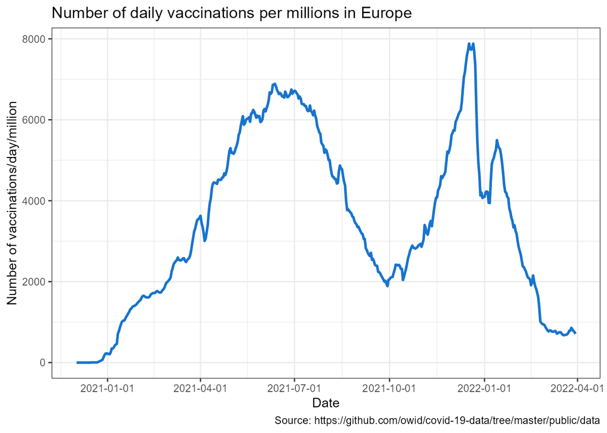

```r
# european countries
df_vacc_europe = df_vacc[df_vacc$iso_code=='OWID_EUR', ]

# number of vaccinations per million per date
vacc_permillion = aggregate(df_vacc_europe$daily_vaccinations_per_million, list(df_vacc_europe$date), FUN=sum)
colnames(vacc_permillion) <- c('date', 'vaccinations')

gg <- ggplot(vacc_permillion, aes(x = date, y = vaccinations)) +
  geom_line(col='dodgerblue3', size=1) +
  labs(title="Number of daily vaccinations per millions in Europe",
       x='Date',
       y='Number of vaccinations/day/million',
       caption = "Source: https://github.com/owid/covid-19-data/tree/master/public/data") +
  scale_x_continuous(
    breaks = seq(as.Date("2021-01-01"), as.Date("2022-04-01"), by = "quarter"),
  ) +
  theme_bw()

plot(gg)
```

Data: https://github.com/owid/covid-19-data/blob/master/public/data/vaccinations/vaccinations.csv